# White-throated Sparrow Wing Length

Daniel Redwine

2023-10-23

# Modelling White-throated Sparrow wing length

Different factors such as sex and morph may serve to predict White-throated Sparrow wing chord length. Here we will use model selection and information criterion to examine the best predictors of White-throated Sparrow wing chord length.

[interactive chart not shown]

Figure 1. Photograph of a White-throated Sparrow from Macaulay Library

# Model Multicollinearity and Assumptions

```
## Analysis of Variance Table
##
## Response: Wing
##                  Df Sum Sq Mean Sq  F value    Pr(>F)
## PCRsex            1 460.10  460.10 129.8214 < 2.2e-16 ***
## PCRMorph          1  46.26   46.26  13.0539  0.000428 ***
## Mass              1  60.43   60.43  17.0511 6.389e-05 ***
## Banded_Location   1   3.64    3.64   1.0267  0.312766
## Residuals       133 471.37    3.54
## ---
## Signif. codes:  0 '***' 0.001 '**' 0.01 '*' 0.05 '.' 0.1 ' ' 1
```

Output of anova() for the model containing all of the predictors.

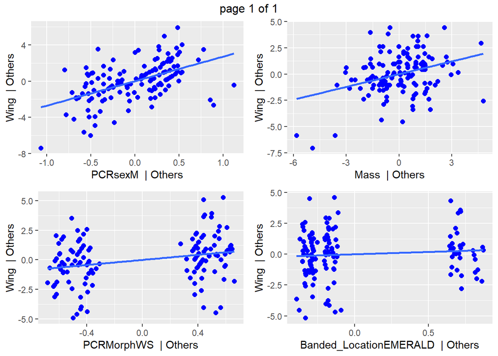

Figure 2. Regression plots for sex, morph, location, and mass adjusted for all other variables. Note that sex, morph and location are categorical predictors.

I’m unsure how sex, morph, and location are altered given that they are categorical predictors.

```
## # Check for Multicollinearity
##
## Low Correlation
##
##             Term  VIF   VIF 95% CI Increased SE Tolerance Tolerance 95% CI
##           PCRsex 1.39 [1.19, 1.80]         1.18      0.72     [0.56, 0.84]
##         PCRMorph 1.04 [1.00, 4.53]         1.02      0.96     [0.22, 1.00]
##             Mass 1.35 [1.16, 1.75]         1.16      0.74     [0.57, 0.86]
##  Banded_Location 1.03 [1.00, 5.76]         1.02      0.97     [0.17, 1.00]
```

VIF values start at one. Generally a VIF of 5 or 10 indicates multicollinearity. All VIF values are close to one for this model.

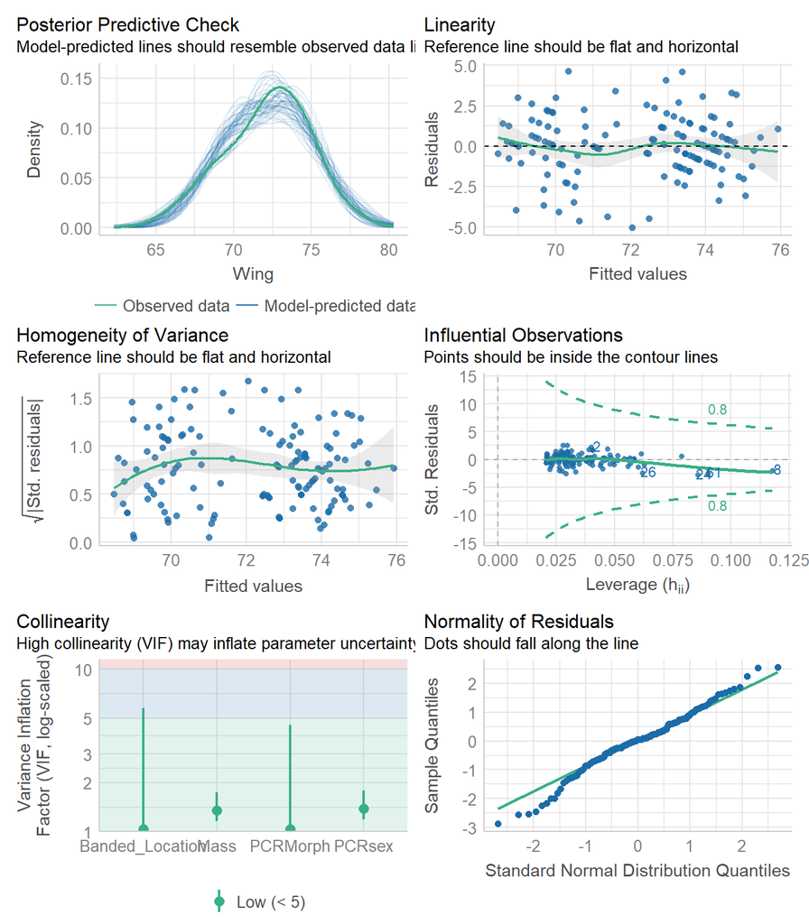

Figure 3. Assumptions for the model predicting wing chord length (mm) by sex, morph, mass, and location

The model seems to fit assumptions. Predicted values adhere to actual values and low VIF indicates that multicollinearity is not an issue.

# Model Selection

```
## Global model call: lm(formula = Wing ~ PCRsex + PCRMorph + Mass + Banded_Location,
##     data = wtsp_data_clean)
## ---
## Model selection table
##    (Int) Bnd_Lct    Mss PCRM PCRs df   logLik  AICc  delta weight
## 15 59.43         0.4012    +    +  5 -281.103 572.7   0.00  0.627
## 16 59.28       + 0.4044    +    +  6 -280.572 573.8   1.13  0.357
## 11 59.16         0.4297         +  4 -286.254 580.8   8.15  0.011
## 12 59.04       + 0.4327         +  5 -285.930 582.3   9.65  0.005
## 13 69.42                   +    +  4 -289.366 587.0  14.37  0.000
## 14 69.36       +           +    +  5 -289.012 588.5  15.82  0.000
## 9  69.91                        +  3 -295.084 596.3  23.69  0.000
## 10 69.87       +                +  4 -294.903 598.1  25.45  0.000
## 8  51.97       + 0.7370    +       5 -302.374 615.2  42.54  0.000
## 7  51.90         0.7481    +       4 -304.239 616.8  44.12  0.000
## 4  51.24       + 0.7908            4 -308.184 624.7  52.01  0.000
## 3  51.20         0.7999            3 -309.655 625.5  52.83  0.000
## 6  71.00       +           +       4 -326.221 660.7  88.08  0.000
## 5  71.27                   +       3 -328.210 662.6  89.94  0.000
## 2  71.91       +                   3 -333.733 673.6 100.99  0.000
## 1  72.15                           2 -335.294 674.7 102.02  0.000
## Models ranked by AICc(x)
```

All possible models generated with dredge(). Note that there are 16 total models and each predictor appears eight times.

```
## Global model call: lm(formula = Wing ~ PCRsex + PCRMorph + Mass + Banded_Location,
##     data = wtsp_data_clean)
## ---
## Model selection table
##    (Int) Bnd_Lct    Mss PCRM PCRs df   logLik  AICc delta weight
## 15 59.43         0.4012    +    +  5 -281.103 572.7  0.00  0.627
## 16 59.28       + 0.4044    +    +  6 -280.572 573.8  1.13  0.357
## 11 59.16         0.4297         +  4 -286.254 580.8  8.15  0.011
## 12 59.04       + 0.4327         +  5 -285.930 582.3  9.65  0.005
## Models ranked by AICc(x)
```

Models within 10 AICc of the top model. Note that the top two are the only models within two AICc. Most of the model weight is between the top two equivalent models.

```
## Global model call: lm(formula = Wing ~ PCRsex + PCRMorph + Mass + Banded_Location,
##     data = wtsp_data_clean)
## ---
## Model selection table
##    (Int) Bnd_Lct    Mss PCRM PCRs df   logLik  AICc delta weight
## 15 59.43         0.4012    +    +  5 -281.103 572.7  0.00  0.637
## 16 59.28       + 0.4044    +    +  6 -280.572 573.8  1.13  0.363
## Models ranked by AICc(x)
```

The two equivalent models within two AICc. Note that one includes banded location while the other model does not.

```
##                      PCRsex Mass PCRMorph Banded_Location
## Sum of weights:      1.00   1.00 0.98     0.36
## N containing models:    8      8    8        8
```

Adjusted weights for each individual variable as they appear in eight out of the sixteen models. Note that sex, morph, and mass have a higher weight than location banded.

```
##
## Call:
## model.avg(object = dredge_wing, revised.var = TRUE)
##
## Component models:
## '234'    '1234'   '24'     '124'    '34'     '134'    '4'      '14'     '123'    '23'
## '12'     '2'      '13'     '3'      '1'      '(Null)'
##
## Coefficients:
##        (Intercept)      Mass PCRMorphWS  PCRsexM Banded_LocationEMERALD
## full        59.381 0.4025435   1.041375 2.753877              0.1371099
## subset      59.381 0.4028299   1.057957 2.753877              0.3785207
```

Average of coefficients between all models.

```
##
## Call:
## model.avg(object = dredge_wing, subset = delta < 2)
##
## Component model call:
## lm(formula = Wing ~ <2 unique rhs>, data = wtsp_data_clean)
##
## Component models:
##      df  logLik   AICc delta weight
## 234   5 -281.10 572.66  0.00   0.64
## 1234  6 -280.57 573.79  1.13   0.36
##
## Term codes:
## Banded_Location            Mass        PCRMorph          PCRsex
##               1               2               3               4
##
## Model-averaged coefficients:
## (full average)
##                        Estimate Std. Error Adjusted SE z value Pr(>|z|)
## (Intercept)            59.37790    2.43832     2.46059  24.132  < 2e-16 ***
## Mass                    0.40239    0.09720     0.09809   4.102 4.09e-05 ***
## PCRMorphWS              1.05787    0.32637     0.32935   3.212  0.00132 **
## PCRsexM                 2.75145    0.38320     0.38668   7.116  < 2e-16 ***
## Banded_LocationEMERALD  0.13775    0.29022     0.29183   0.472  0.63693
##
## (conditional average)
##                        Estimate Std. Error Adjusted SE z value Pr(>|z|)
## (Intercept)            59.37790    2.43832     2.46059  24.132  < 2e-16 ***
## Mass                    0.40239    0.09720     0.09809   4.102 4.09e-05 ***
## PCRMorphWS              1.05787    0.32637     0.32935   3.212  0.00132 **
## PCRsexM                 2.75145    0.38320     0.38668   7.116  < 2e-16 ***
## Banded_LocationEMERALD  0.37955    0.37457     0.37801   1.004  0.31535
## ---
## Signif. codes:  0 '***' 0.001 '**' 0.01 '*' 0.05 '.' 0.1 ' ' 1
```

Average of coefficients between only the top two models.

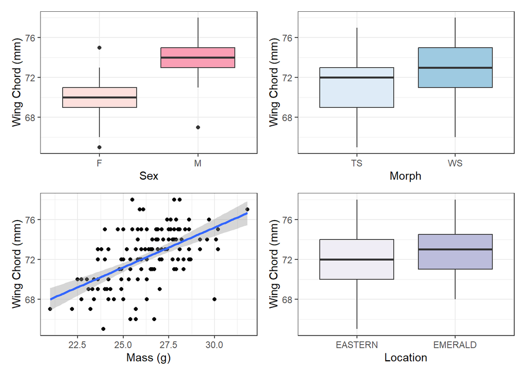

Figure 4. Graphs of wing chord length (mm) for, sex, morph, location, and mass